# Logistic Map 综合

2025-10-8

课程代码均在如下 GitHub 仓库开源：https://github.com/GHe0000/scientific-programming-intro

> 注：由于计算和图片较多，从头运行大概需要 40 秒.

## 目录

- 作业要求
- 解析求解周期一和周期二轨道及其稳定的参数范围
  - 基本思路
  - 周期一
  - 周期二
  - 为何会出现 Overflow
- 全周期分叉图
  - 分叉图
  - 周期三
  - 周期五
- 全参数范围的李雅普诺夫指数
- 倍周期分叉点、$r_{\infty}$、费根鲍姆常数
  - 倍周期分叉点
  - $r_{\infty}$
  - 验证倍周期分叉点和 $r_{\infty}$
  - 费根鲍姆常数
- 选做内容：数值计算李雅普诺夫指数
- 结论
- 参考资料
- 致谢
- 附一：问题
- 附二：学习心得

## 作业要求

对映射 $x_{n+1} = r - x_n^2,\quad r\in[0,2],\quad x\in[-2,2]$ 做如下分析：

- 解析求解周期一和周期二轨道及其稳定的参数范围，并用数值验证
- 画出全参数分叉图，并放大显示某个周期三、周期五区域
- 利用解析公式计算全参数范围的李雅普诺夫指数，是否跟分岔图解释的现象一致？
- 利用全参数范围的李雅普诺夫指数确定倍周期分岔点以及 $r_{\infty}$，利用倍周期分岔点的参数计算费根鲍姆常数 $\delta$，是否跟 Logistic map 一致？

选做内容（只选其一）：

- 定量分析临界慢化: 倍周期分岔过程中，当参数趋向分岔点时，轨道趋向吸引子的速度会变慢，定量数值研究收敛速度与参数到分岔点距离的依赖关系，不同的分岔点规律是否一致？
- 数值计算李雅普诺夫指数：根据课堂介绍的数值方法计算李指数，并挑选若干参数跟解析结果对比。

要求：排版简洁规范，结构完整。要有必要的文字描述解题思路、编程逻辑、现象分析和总结。

## 解析求解周期一和周期二轨道及其稳定的参数范围

### 基本思路

对于映射 $x_{n+1} = r-x^2_{n}$，我们定义迭代函数：

$$ f(x) = r - x^2,\quad x_{n+1} = f(x_n) $$

同时我们定义：

$$ f^n (x) = \underbrace{\left( f \circ f \circ \dots \circ f \right)}_{n \text{个} f} (x)$$

要求解周期一的轨道，就是要求解 $f(x)$ 的不动点，即求解方程 $x^* = f(x^*)$，而不动点的稳定性可以通过局部稳定判据进行判断，也就是计算 $|f'(x^*)|$ 并和 $1$ 进行对比，求解出 $|f'(x^*)|<1$ 的 $r$ 的范围就是周期一轨道的稳定的参数范围.

而周期二的轨道，就是要求解 $f^2(x)$ 的不动点，即求解方程 $x^* = f^2(x^*)$，并类似地计算 $|(f^2)' (x^*)|$ 进行局部稳定性的判断.

### 周期一

#### 解析求解

这里我们先导入需要的库，并针对 Jupyter Notebook 进行一些设置.

这里我们定义一个函数 `fn`，从而方便地得到任意的 $f^n (x)$ 函数. 并以此定义 $f(x)$（记为 $f^1(x)$）

$\displaystyle f(x)=r - x^{2}$

计算 $f(x)$ 的不动点 $x^*$，并计算 $f'(x)$，将 $x^*$ 带入 $f'(x)$：

$\displaystyle \text{函数 } f(x)=r - x^{2}\text{ 一共找到 2 个不动点：}$

$\displaystyle x^*=- \frac{\sqrt{4 r + 1}}{2} - \frac{1}{2},\quad x^*=\frac{\sqrt{4 r + 1}}{2} - \frac{1}{2},\quad $

$\displaystyle f(x) \text{ 的导数为 }f'(x)=- 2 x\text{, 带入 } x^* \text{ 有：}$

$\displaystyle f'\left(- \frac{\sqrt{4 r + 1}}{2} - \frac{1}{2}\right)=\sqrt{4 r + 1} + 1$

$\displaystyle f'\left(\frac{\sqrt{4 r + 1}}{2} - \frac{1}{2}\right)=1 - \sqrt{4 r + 1}$

由于 $r\in[0,2]$，因此 $\sqrt{4r+1}+1>1$，不动点：

$$ x^* = \frac{-\sqrt{4r+1}-1}{2} $$

一定是不稳定的. 而不动点：

$$ x^* = \frac{\sqrt{4r+1}-1}{2} $$

若是稳定的，则需要：

$$ \left| 1-\sqrt{4r+1} \right| < 1 $$

解得：$ r < \frac{3}{4} $. 因此，当 $0<r<\frac{3}{4}$ 时，系统有稳定的周期一轨道：

$$ \dots \to \frac{\sqrt{4r+1}-1}{2} \to \frac{\sqrt{4r+1}-1}{2} \to \dots $$

#### 数值验证

为了方便后面绘制迭代过程，我们将绘制迭代过程抽象成一个函数：

给定 $r=0.5$，我们在 $x\in[-2,2]$ 之间均匀采样 $5$ 个点，绘制其迭代过程：

```
/tmp/ipykernel_585326/3616708647.py:5: RuntimeWarning: overflow encountered in square
  ax = plot_orbit(ax, lambda r,x:r-x**2, np.linspace(-2,2,5), r, n, markersize=4, marker='o', linestyle='--')
```

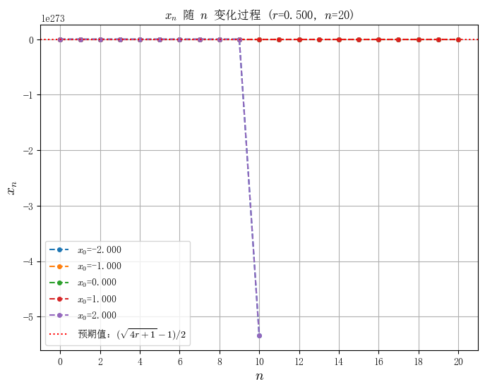

可以发现，出现了 Overflow 的警告，同时图像的坐标轴被放很大，我们设置一下人为忽略 Overflow 的警告（在后面的章节会对其进行具体分析），并限制一下 $y$ 轴的范围：

> 为了显示出现了 Overflow，上面代码保留了出现的警告，后文中会经过处理来消除.

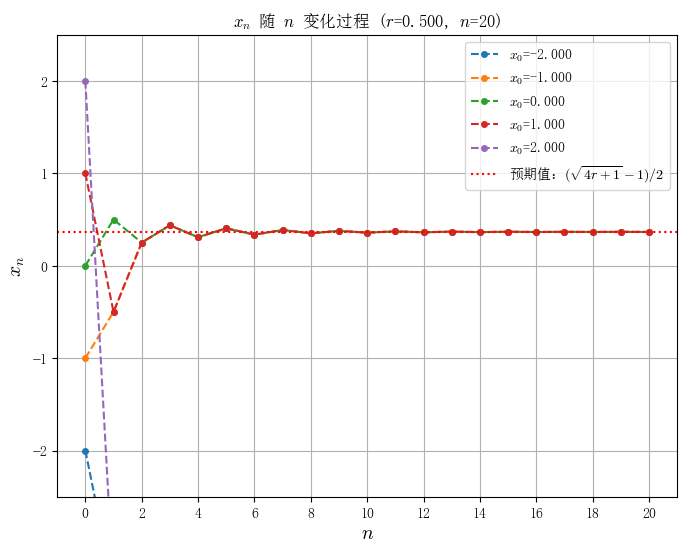

我们选取更多的 $x_0$ 查看变化过程：

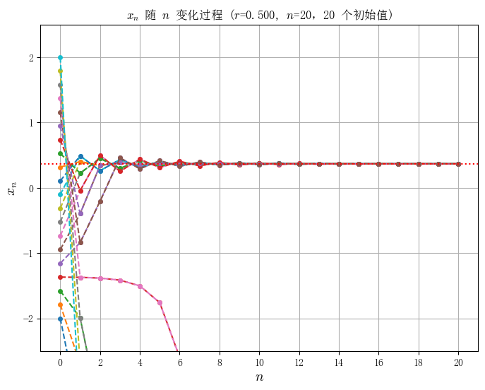

可以看到，对于某些 $x_0$，$x_n$ 最终到达稳定的周期一轨道，而对于另外的 $x$，$x_n$ 最终会到达 $- \infty$

我们根据 $x_n$ 最后是否收敛到周期一轨道对线条进行染色，并加大 $x_0$ 采样的密度：

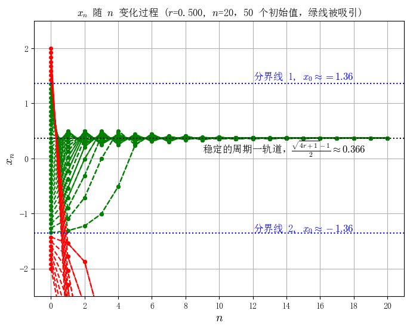

可以看到，当初始值在两条分界线之间时，$x_n$ 收敛到周期一轨道，反之到达 $-\infty$.

我们将收敛到周期一轨道的 $x_0$ 构成的集合称为该轨道的**吸引域**，下面我们尝试求解吸引域的范围.

#### 解析估计吸引域

前面我们通过导数对周期一轨道进行稳定性判断的方法依赖于 Taylor 展开，也就是其只能在吸引子附近的邻域内才能使用. 对于 $|f'(x^*)|<1$ 只能说明其在不动点周围的小邻域范围内是吸引的，对于全取值范围内不一定能使用. 因此，要计算（或者估计）吸引域的范围，需要一些新的方法.

首先想到的是数学分析中的 Banach 压缩映射定理，其要求在某个不变的完备度量空间 $(X,d)$，映射 $T$ 是压缩映射，即 $\forall x,y\in X$ 满足：

$$ d(T(x),T(y)) \leq \lambda d(x,y),\quad (0\leq \lambda <1 ) $$

则 $T$ 在 $X$ 上存在且仅存在一个不动点 $x^*$，即 $T(x^*)=x^*$，且 $\forall x_0 \in X$，迭代 $x_{n+1} = T(x_n)$ 均收敛到唯一的不动点 $x^*$，且收敛速度至少是几何级数，即：

$$ d(x_n,x^*) \leq \frac{\lambda^n}{1-\lambda} d(x_1,x_0) $$

对于一维系统，取常规的距离度量，给定区间 $I$，由 Lagrange 中值定理，有：

$$ |f(x)-f(y)| = |f'(\xi)| |x-y| \leq \max_{x\in I} |f'(x)| |x-y|,\quad (\xi \in I) $$

因此 Banach 压缩映射条件可以变为：

$$ |f'(x)|\leq \lambda < 1,\ \forall x \in I $$

因此，对于映射 $f(x)=r-x^2$，如果我们能找到一个区间 $I$，使得 $f(I)\subset I$，并且：

$$ |f'(x)| \leq \lambda < 1, \forall x\in I $$

那么根据 Banach 压缩映射定理，所有初始值在 $I$ 的点最终都会收敛到 $I$ 中唯一的不动点. 则区间 $I$ 一定是吸引域的子集.

且显然可以得到推论，如果 $|f'(x)|>1$ 则该点必然是排斥的.

上述过程的麻烦之处在于找到区间 $I$，使得 $f(I)\in I$. 根据对称性，我们假设区间 $I \in (-M,M)$，因此，$M$ 的最大值满足：

$$ r-M_1^2 = M_1,\ r-M_2^2=-M_2,\ M=\max\{|M_1|,|M_2|\} $$

即：

$$ M=\max\left\{ \left| \frac{\pm\sqrt{4r+1}-1}{2} \right| , \left| \frac{\pm\sqrt{4r+1}+1}{2} \right| \right\} = \frac{\sqrt{4r+1}+1}{2}$$

因此，若 $x_0 \in [-M,M]$，能保证在之后的迭代中一定不超过 $[-M,M]$（至于是否收敛到周期一需要计算导数.）

对于 $f(x)=r-x^2$，$|f'(x)|<1$ 解得 $-1/2 < x < 1/2$，同时 $1/2 < M$，因此由 Banach 压缩映射，我们知道 $[-1/2,1/2]$ 是周期一轨道的吸引域的子集.

这个估计非常保守，这是因为此范围保证了 $f(x)$ 是压缩映射，但是实际上有可能 $f(x)$ 不是压缩映射，但 $f^n(x)$ 是压缩映射，显然这种情况最后也会收敛到不动点，因此使得估计的范围过小.

而 $[-M,M]$ 保证了一旦 $x_n$ 落入这个范围，则 $x_n$ 之后一定保持在这个范围内，根据前面的数值验证，对于存在稳定的周期一轨道的情况，如果 $x_n$ 不趋向 $\pm\infty$，则 $x_n$ 最终收敛于周期一轨道，因此我们可以将 $[-M,M]$ 作为周期一轨道的一个估计.

（但证明 $\forall x_0 \in [-M,M]$ 均收敛到周期一轨道需要借助 Banach 定理通过更精细的分析和估计来证明，能力有限不进一步证明.）

我们将估计的吸引域范围绘制在图上.

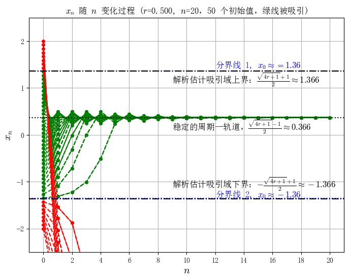

可以发现我们的估计还是比较准确的.

#### 数值计算吸引域

前面我们尝试通过解析的方式估计吸引域，但需要通过精细的分析来估计，非常麻烦且个人能力有限. 目前仅猜测 $[-M,M]$ 是周期一的吸引域. 其中：

$$ M = \frac{\sqrt{4r+1}+1}{2} $$

这里我们将尝试通过数值的方法找到吸引域的范围.

首先，由于 $f(x)$ 是关于 $x=0$ 对称的，根据对称性我们可以合理的认为吸引域也是关于 $x=0$ 对称的. 同时，观察前面的收敛图，可以知道吸引域满足 $(-N,N)$，因此，要计算周期一的吸引域，就是要确定 $N$. 这里使用二分法来寻找.

1. 给定一个初始范围 $(N_1, N_2)$，保证边界 $N$ 落在这个范围内
2. $N_x = (N_1 + N_2) / 2$，以 $N_x$ 为初始值迭代，若 $N_x$ 在周期一轨道或者得到 `inf` 结束迭代
3. 若在周期一轨道，更新 $N_2 \to N_x$，若得到 `inf`，更新 $N_1 \to N_x$
4. 回到第二步，直到 $N_2-N_1$ 小于给定范围，则 $N_x$ 为最后结果.

带入 $r=0.5$，初始边界取 $(0,2)$，计算吸引域边界：

```
r=0.5 时正半轴吸引域边界：1.366025447845459
```

可以发现和前面我们通过图像确定的值接近，说明上述算法是有效的，我们在 $r\in[0,3/4]$ 内寻找吸引域边界，并绘图：

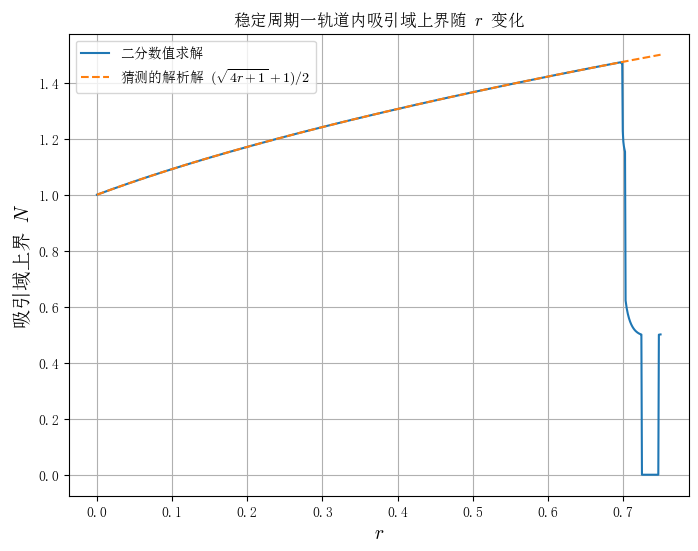

可以发现前面符合很好，但是到 $0.7$ 附近突然发生了变化，我们挑选 $r=0.74$ 查看情况：

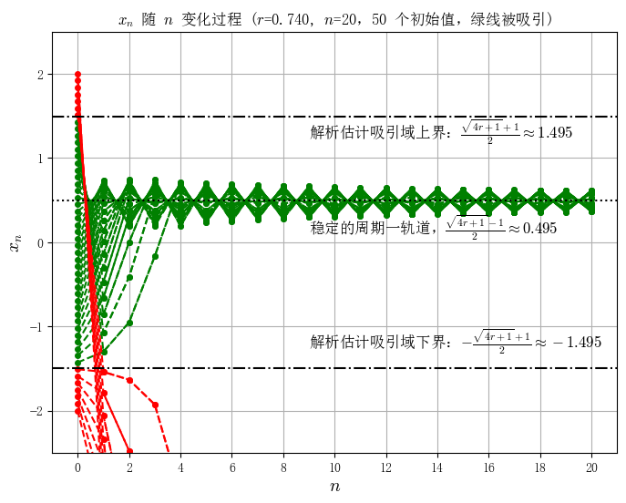

可以发现我们的估计和实际的分界还是吻合的. 同时当 $r$ 接近分叉点 $3/4$ 出现了临界慢化现象，导致二分查找中判断是否收敛时实际是收敛的，但是因为临界慢化现象，结束计算时仍未收敛到判定为收敛的小范围内，从而导致二分查找出现问题.

这里我们加大收敛的判定范围，同时增大判断时的迭代过程重新绘图.

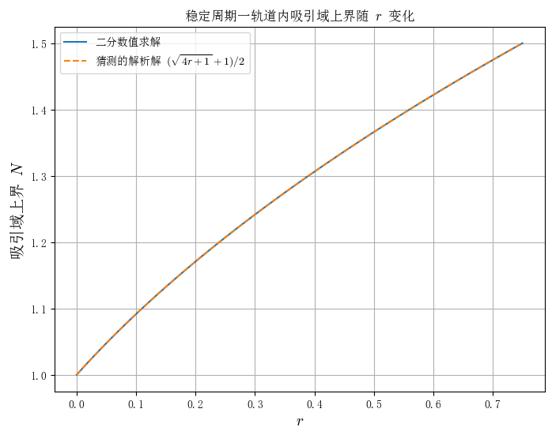

可以发现在整个周期一范围内数值求解的吸引域和我们估计的解析解基本吻合.

### 周期二

#### 解析求解

类似周期一，定义 `f2`：

$\displaystyle f^2(x)=r - \left(r - x^{2}\right)^{2}$

计算 $f^2(x)$ 的不动点 $x^*$，并计算 $(f^2)'(x)$，将 $x^*$ 带入 $(f^2)'(x)$：

$\displaystyle \text{函数 } f^2(x)=r - \left(r - x^{2}\right)^{2}\text{ 一共找到 4 个不动点：}$

$\displaystyle x^*=\frac{1}{2} - \frac{\sqrt{4 r - 3}}{2},\quad x^*=\frac{\sqrt{4 r - 3}}{2} + \frac{1}{2},\quad x^*=- \frac{\sqrt{4 r + 1}}{2} - \frac{1}{2},\quad x^*=\frac{\sqrt{4 r + 1}}{2} - \frac{1}{2},\quad $

$\displaystyle f^2(x) \text{ 的导数为 }(f^2)'(x)=4 x \left(r - x^{2}\right)\text{, 带入 } x^* \text{ 有：}$

$\displaystyle (f^2)'\left(\frac{1}{2} - \frac{\sqrt{4 r - 3}}{2}\right)=4 - 4 r$

$\displaystyle (f^2)'\left(\frac{\sqrt{4 r - 3}}{2} + \frac{1}{2}\right)=4 - 4 r$

$\displaystyle (f^2)'\left(- \frac{\sqrt{4 r + 1}}{2} - \frac{1}{2}\right)=4 r + 2 \sqrt{4 r + 1} + 2$

$\displaystyle (f^2)'\left(\frac{\sqrt{4 r + 1}}{2} - \frac{1}{2}\right)=4 r - 2 \sqrt{4 r + 1} + 2$

$f^2(x)$ 的不动点一共有四个，可以分成下面两组：

$$ x^* = \frac{1\pm\sqrt{4r-3}}{2}, \quad x^* = \frac{\pm\sqrt{4r+1}-1}{2} $$

其中第二组就是之前我们求解出的周期一轨道，显然周期一轨道也是周期二轨道. 而第一组是新出现的周期二轨道. 且第一组的两个不动点的稳定条件相同，都是 $|4-4r|<1$，下面我们分别讨论每一个不动点的稳定性.

要使得不动点： $$ x^* = \frac{1\pm\sqrt{4r-3}}{2} $$ 稳定，则 $|4-4r|<1$，解得：$\frac{3}{4} < r < \frac{5}{4}$. 因此，当 $\frac{3}{4} < r < \frac{5}{4}$ 时，系统有稳定的周期二轨道：

$$ \dots \to \left( \frac{1+\sqrt{4r-3}}{2} \to \frac{1-\sqrt{4r-3}}{2} \right) \to \left( \frac{1+\sqrt{4r-3}}{2} \to \frac{1-\sqrt{4r-3}}{2} \right) \to \dots $$

要使得不动点：

$$ x^* = \frac{-\sqrt{4r+1}-1}{2} $$

稳定，则：

$$ |4r + 2\sqrt{4r+1}+2|<1 $$

由于 $r>0$，显然上式无解，因此此不动点不稳定.

要使得不动点：

$$ x^* = \frac{\sqrt{4r+1}-1}{2} $$

稳定，则：

$$ |4r - 2\sqrt{4r+1}+2|<1 $$

解得

$\displaystyle - \frac{1}{4} \leq r \wedge - \frac{1}{4} < r \wedge r < \frac{3}{4} \wedge r < \infty$

也就是 $0<r<\frac{3}{4}$（注意 $r>0$），和周期一轨道的稳定性相同（显然稳定的周期一轨道就是稳定的周期二轨道），并没有显现出和周期一不同的性质，因此这里不计入周期二轨道的范围内.

综上，当 $\frac{3}{4} < r < \frac{5}{4}$ 时，系统有稳定的周期二轨道：

$$ \dots \to \left( \frac{1+\sqrt{4r-3}}{2} \to \frac{1-\sqrt{4r-3}}{2} \right) \to \left( \frac{1+\sqrt{4r-3}}{2} \to \frac{1-\sqrt{4r-3}}{2} \right) \to \dots $$

#### 数值验证

给定 $r=1$，我们在 $x\in[-2,2]$ 之间均匀采样 $5$ 个点，绘制其迭代过程：

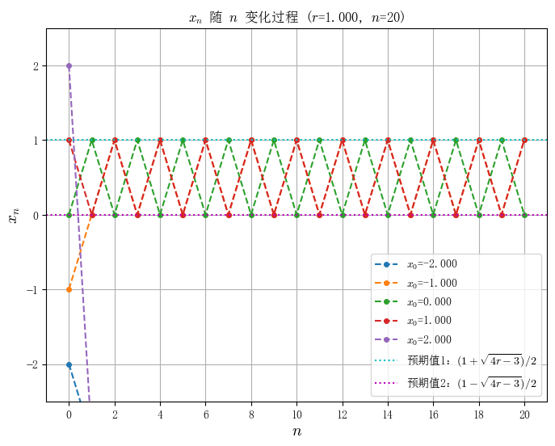

可以发现同样有部分范围的 $x_0$ 发散到 $-\infty$，我们选取更多的 $x_0$ 并将吸引到周期二轨道的轨迹染成绿色：

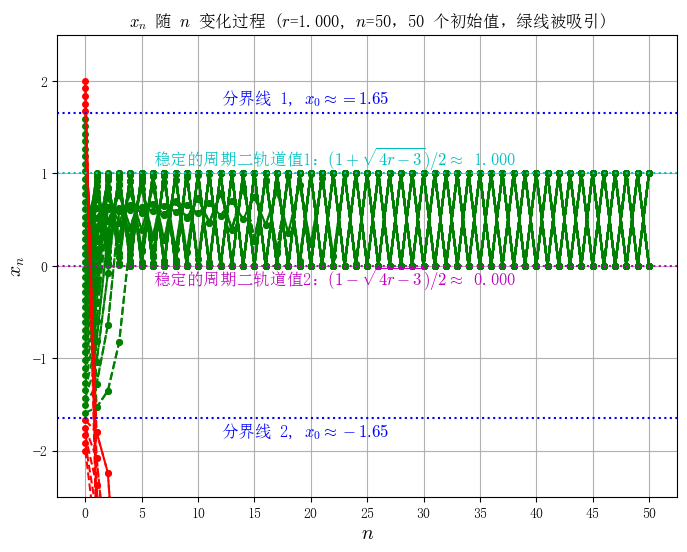

同样可以看到，类似周期一的情况，当初始值在两条分界线之间时，$x_n$ 收敛到周期二轨道，反之到达 $-\infty$.

对于周期二，我们除了可以关注是否被周期二轨道吸引外，还可以关注是吸引到 $p_1 \to p_2 \to \dots $ 还是 $p_2 \to p_1 \to \dots $，其中 $p_{1,2}$ 是周期二轨道的两个值：

$$ p_{1,2} = \frac{1+\pm\sqrt{4r-3}}{2} $$

我们根据最后一次迭代是靠近 $p_1$ 还是靠近 $p_2$ 来染色：

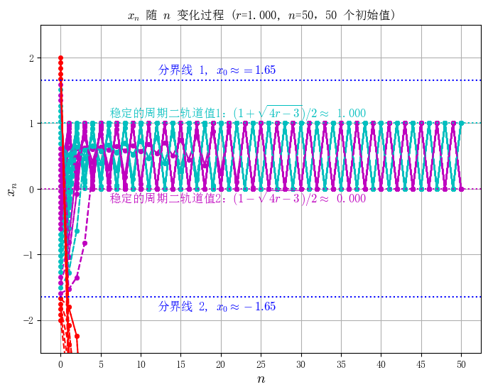

可以看到，在整体的周期二的吸引域内，不同轨道的吸引域呈现某种更精细的结构.

下面我们尝试求解周期二吸引域的范围. 并计算不同轨道的吸引域.

#### 解析估计吸引域

对于整个周期二轨道的吸引域，类似前面的周期一，我们知道，若 $x_0 \in [-M,M]$ 其中：

$$ M = \frac{\sqrt{4r+1}+1}{2} $$

则在整个迭代范围中 $x_n \in [-M,M]$，而前面的数值计算中我们发现对于不同的 $x_0$，其要么趋向 $-\infty$，要么吸引到周期二轨道，因此，我们可以猜测整个周期二轨道的吸引域也为 $[-M,M]$

（如果周期一的吸引域是 $[-M,M]$，那么周期二的吸引域也应为 $[-M,M]$，因为在证明（虽然我没有能力证明）周期一的吸引域是 $[-M,M]$ 等价于证明 $f^n(x)$ 在这个范围内是压缩映射，也因此 $\left(f^{2}\right)^{n/2} (x)$ 也是压缩映射）.

而对于周期二吸引域内两条轨道单独的吸引域，这里暂时没有什么想法进行解析计算或者估计. 如果之后后想法再在这里补充.

解析求解过于困难，下面我们尝试通过数值计算寻找吸引域（尤其是两条轨道各自的吸引域）

#### 数值计算吸引域

首先我们先验证整个周期二轨道的吸引域是否和我们估计的相同：

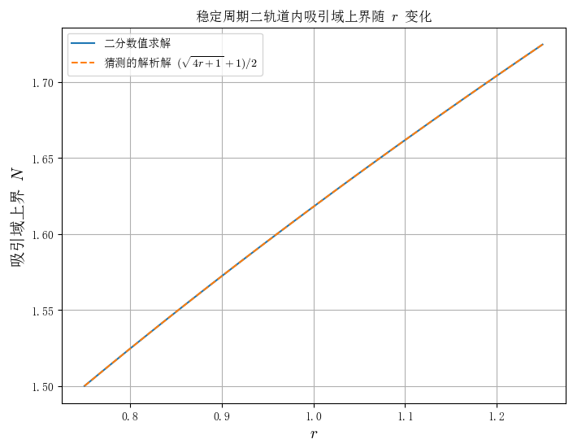

可以看到，在整个稳定的周期二轨道的范围内，数值计算的周期二轨道的吸引域和我们估计的相同，即 $[-M,M]$，且：

$$ M = \frac{\sqrt{4r+1}+1}{2} $$

下面我们寻找整个周期二吸引域内两条轨道各自的吸引域. 由于对称性，显然吸引域是关于 $0$ 对称的，因此下面我们只计算大于 $0$ 的分界点.

和整个周期二吸引域只有一个分界点不同，两条轨道的分界点会有多个，因此这里我们采用如下方法寻找分界点.

这里我们对 $x_0 \in [0,M]$ 进行等间距采样（上界到 $M$ 保证一定会收敛到周期二而不是发散），并迭代一定次数，并判断最后一次迭代收敛到哪一个点，到 $p_1$ 记为 $1$，到 $p_2$ 记为 $0$，从而得到一个数字串：$111122222\dots$，找到里面每一个 $1,2$ 分界处，分界处的两个值的平均就是分界点的估计.

如果需要进一步细化也可以用每个分界处的两个值作为二分查找的初始区间，这里暂时先不用二分查找细化.

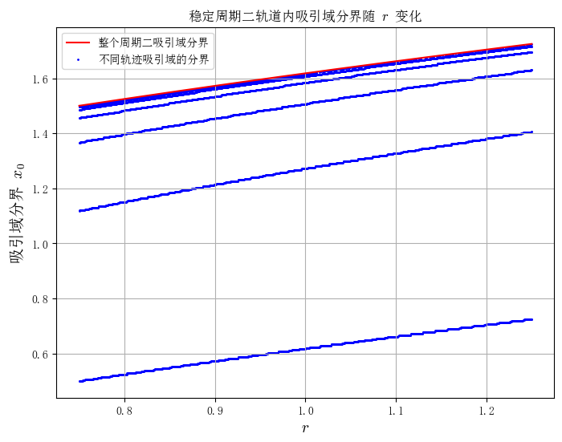

可以发现，在靠近整个周期二吸引域的分界处，不同轨道的吸引域变化很快，我们在附近放大绘制：

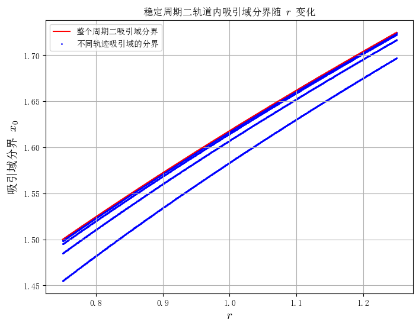

可以看到，越接近这个周期二吸引域的边界，不同轨道的吸引域的分界越密集.

我们可以给图像绘制颜色显示不同初值的最后的去向：

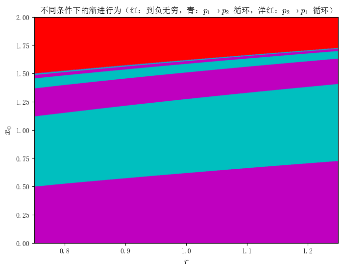

在 $1.5$ 附近放大：

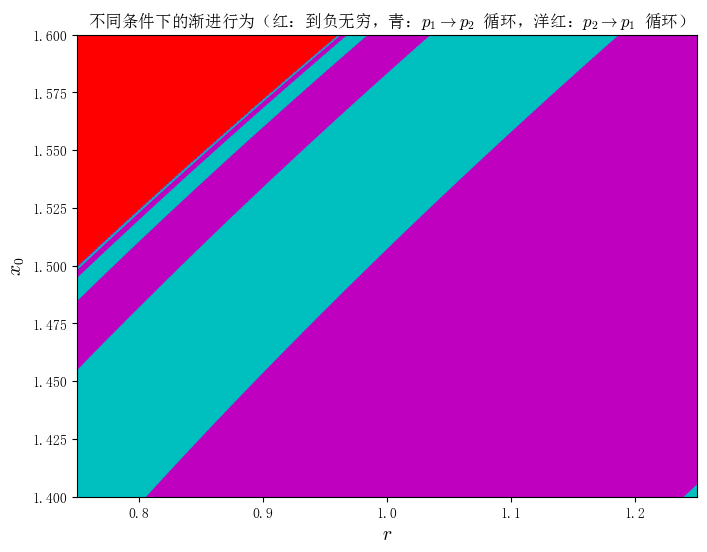

综上，我们知道了周期二轨道的整体的吸引域为 $[-M,M]$，其中：

$$ M = \frac{\sqrt{4r+1}+1}{2} $$

且在整体的吸引域内各条轨迹的吸引域具有丰富细节，且越靠近整体吸引域的边界变化越快.

### 为何会出现 Overflow

在前面的绘制分叉图的过程中，我们遇到了 Overflow 的问题，具体而言，Overflow 发生在当数值非常大或者非常小以至于超过计算机中的表达范围时（在 Python 中默认使用 float64，其最大能保存约 $10^{-308}$ 到 $10^{308}$ 范围内的数值（精度约 16 位）），超过范围的数会变成 inf 或者 -inf 从而无法进一步进行数值计算，并出现 Overflow 问题.

回顾我们绘制分叉图的过程，我们多次迭代计算了 $f(x)=r-x^2$，这里 $r$ 是一个比较小的值（$r\in[0,2]$），因此出现 Overflow 只能出现在计算 $x^2$ 之后. 我们来尝试分析给定定义域 $x\in[-2,2]$ 经过 $f^n (x)$ 后值域 $\left\{ f^n(x) | x \in [-2,2] \right\}$ 中的元素绝对值的最大值（也就是 $\text{max} \left\{ |f^n(x)| \right\} $）的变化：

由于 $f(x)$ 是关于 $x=0$ 对称的开口向下的抛物线，因此 $\text{max} \left\{ |f(x)| \right\} $ 要么出现在 $f(0)$ 要么出现在 $f(2)$（由对称性 $f(-2)=f(2)$，因此不再考虑 $-2$，下同），由于 $\left\{ f(x) \right\}$ 一定是 $[-\text{max} \left\{ |f(x)| \right\},\text{max} \left\{ |f(x)| \right\}]$ 的子集，即：

$$ \left\{ f(x) \right\} \subset [-\text{max} \left\{ |f(x)| \right\},\text{max} \left\{ |f(x)| \right\}] $$

因此 $\text{max} \left\{ |f^2(x)| \right\} $ 要么出现在 $|f(0)|$，要么出现在 $\left| f\left( \text{max} \left\{ |f(x)| \right\} \right) \right|$，后者等价于 $\text{max} \left\{ \left| f^2(0)\right|, \left|f^2(2) \right| \right\}$.

上述过程可以推到 $f^n$，综上：

$$ \text{max} \left\{ |f^n(x)| \right\} = \text{max} \left\{ |f(0)|, \left| f^n (0) \right|, \left| f^n (2) \right| \right\}$$

而由于 $|f^n(2)|$ 当 $r<2$ 时随着 $n$ 增大而增大（比较显然，不写详细证明了），直至 $\infty$，因此，我们知道 $\text{max} \left\{ |f^n(x)| \right\} $ 一定会随着 $n$ 增大而增大，直至到达双精度浮点表示的最大值，从而出现 Overflow.

## 全周期分叉图

### 分叉图

绘制全周期分叉图的方法和第三次作业类似，这里不再进行说明，直接使用上次作业的函数（进行了一点优化）：

在 $r\in[0,2]$ 内均匀采样 $5 \times 10^3$ 个点，$x\in[-2,2]$ 内均匀随机选取 $20$ 个点，记录最后 $100$ 次的值（一个 $r$ 一共产生 $2\times 10^3$ 个点）.

这里我们忽略最终到达 $\pm \infty$ 的点（也就是我们只记录被吸引的点）

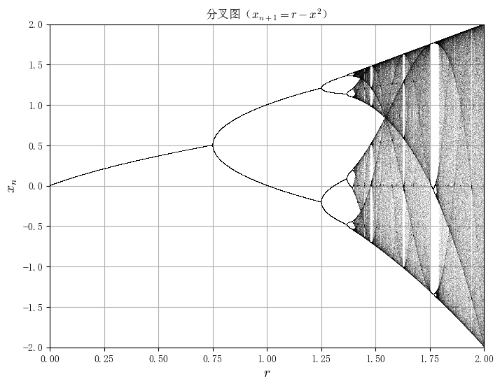

可以看见我们得到了一个类似前一次作业的 Logistic Map 的分叉图.

### 周期三

#### 数值确定周期三位置

从全周期分叉图中我们可以看到，大概在 $r=1.75$ 附近出现周期三轨道. 这里我们针对这附近的范围进行放大：

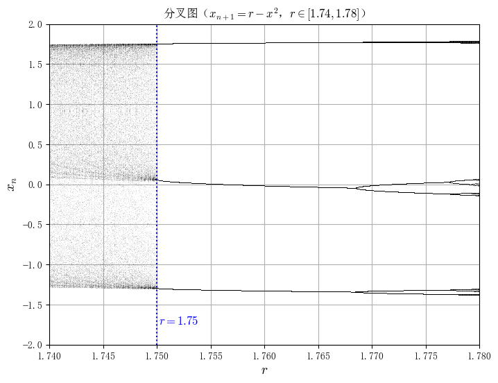

可以看到，确实在 $r=1.75$ 附近出现周期三轨道. 我们绘制迭代过程验证：

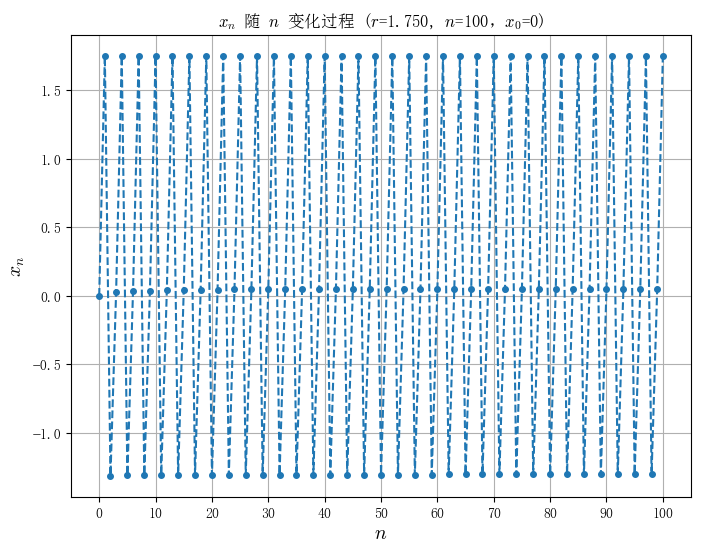

#### 解析求解周期三位置

实际上，周期三轨道的 $r$ 是可以通过解析求解的，我们绘制 $y=f^3(x)$ 和 $y=x$（取 $r=1.75$）

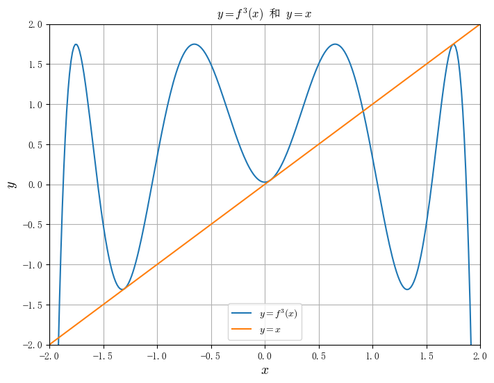

可以发现，要出现周期三，需要 $f^3(x)$ 和 $x$ 出现“相切”，因此，要出现周期三，需要满足以下两个方程：

- $x^* = f^3(x^*)$
- $(f^3)'(x^*)=1$

两个方程解两个未知数（$x^*$ 和 $r$），因此是可以解的，下面使用 `sympy` 给出解析解：

定义两个方程：

$\displaystyle r - x - \left(r - \left(r - x^{2}\right)^{2}\right)^{2}=0$

$\displaystyle - 8 x \left(r - x^{2}\right) \left(r - \left(r - x^{2}\right)^{2}\right) - 1=0$

对于多项式，根据数学上有关多项式的理论，我们可以通过计算结式（Resultant）来消去 $x$，从而得到关于 $r$ 的多项式方程：

$\displaystyle 0=- 16777216 r^{12} + 100663296 r^{11} - 251658240 r^{10} + 384827392 r^{9} - 449839104 r^{8} + 402653184 r^{7} - 275767296 r^{6} + 160161792 r^{5} - 59006976 r^{4} + 21512960 r^{3} + 823543$

因式分解，有：

$\displaystyle 0=- \left(4 r - 7\right)^{3} \left(4 r + 1\right) \left(16 r^{2} - 4 r + 7\right)^{4}$

显然，上面三个因式有且只有第一个有大于 $0$ 的实根，根为：

$$ r = \frac{7}{4} = 1.75 $$

由此我们证明了当出现周期三时，$r=7/4$.

> 注：上述过程对于 Logistic Map 同样适用，可以解得对于原始的 Logistic Map：$x_{n+1} = r x_n (1-x_n) $，其周期三轨道出现在 $r=1+2\sqrt{2}$

### 周期五

从全周期分叉图中我们可以看到，大概在 $r=1.625$ 附近出现周期五轨道. 这里我们针对这附近的范围进行放大：

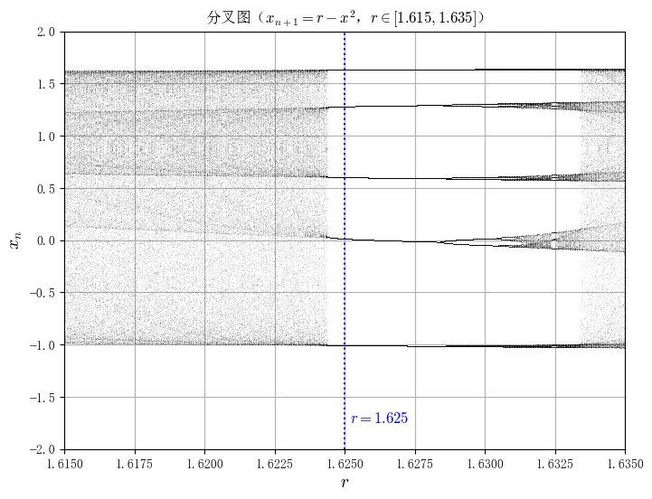

可以看到，确实在 $r=1.625$ 附近出现周期五轨道. 我们绘制迭代过程验证：

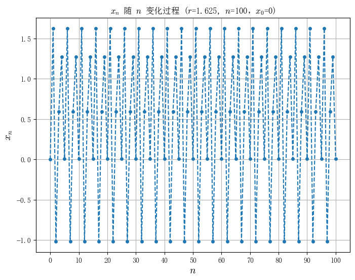

可以发现，当 $r=1.625$ 时确实出现了周期五轨道.

## 全参数范围的李雅普诺夫指数

### 计算思路

根据李雅普诺夫指数的定义，对于微扰 $\delta_0$，迭代 $n$ 次后，有：

$$ \delta_n = \delta_0 \mathrm{e}^{\lambda n} $$

因此：

$$ \lambda = \frac{1}{n} \ln \frac{\delta_n}{\delta_0} = \frac{1}{n} \ln |(f^n)'(x)| = \frac{1}{n} \sum_{k=1}^n |f'(x_k)|$$

从而得到计算思路，对于一个 $r$，经过 $n_{\text{warm}}$ 去除暂态后，迭代 $n$ 次，记录 $\ln|f'(x_k)|$ 的和 $S$，最后 $\lambda = S/n$

### 绘制

考虑到之后可能会对不同的迭代过程绘制全参数范围的李雅普诺夫指数，这里将上述的通过解析表达式的计算过程抽象成一个函数（为了加快速度，要求 `f` 和 `df` 是向量化的）.

在 $r\in[0,2]$ 内均匀采样 $1 \times 10^4$ 个点，取 $x_0 = 0.1$，记录最后 $200$ 次的值来计算李雅普诺夫指数. 并绘制计算得到的李雅普诺夫指数和 $r$ 的关系：

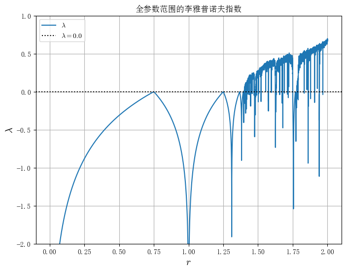

这里我们和前面的分叉图一同显示：

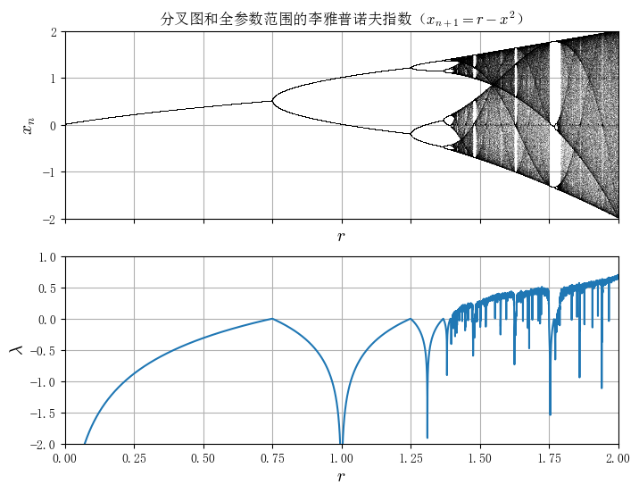

可以发现，李雅普诺夫指数 $\lambda=0$ 时开始分叉，$\lambda>0$ 时出现混沌，当 $\lambda$ 很小时（实际上应该趋向于 $-\infty$，但是由于计算和绘图限制，没有显示）为超稳定轨道（对应 $x_n = 0$ 在最后的轨道中）.

## 倍周期分叉点、$r_{\infty}$、费根鲍姆常数

### 倍周期分叉点

根据前面的李雅普诺夫指数和分叉图的图可以发现，对于每一个倍周期分叉点，其李雅普诺夫指数都有 $\lambda=0$. 因此，我们可以搜索全参数范围的李雅普诺夫指数中约等于 $0$ 的点.

```
array([0.74827483, 0.74847485, 0.74867487, 0.74887489, 0.74907491,
       0.74927493, 0.74947495, 0.74967497, 0.74987499, 0.75007501,
       0.75027503, 0.75047505, 0.75067507, 1.24912491, 1.24932493,
       1.24952495, 1.24972497, 1.24992499, 1.25012501, 1.25032503,
       1.36773677, 1.36793679, 1.36813681, 1.39393939, 1.39413941,
       1.40114011, 1.40134013, 1.40194019, 1.52215222])
```

可以看到，受限于计算精度，在设置允差为 $2 \times 10^{-3}$ 时我们找到了一堆可能的点. 当然我们可以通过更精细地设置允差来给出更好的筛选，但这个过程太依赖于我们的人工观察和经验（判断允差是否合适使得没有多余点也没有少点是依赖于人的观察的）.

当然，上述结果可以尝试再通过聚类等方式进行优化. 这里则使用另外一种方式更好地找到倍周期分叉点：

#### 初筛

首先，比较麻烦的是如何给定包含且只包含一个倍周期分叉点的小区间作为初始区间，这里我们采用如下办法：

1. 在某个范围内均匀取 $r$.
2. 对于某个 $r$，经过 $n_{warm}$ 后，开一个数组
3. 记录 $x_n$，如果数组中没有（距离数组中的元素小于 `tol`），则添加到数组中，并再迭代一次，否则认为出现循环，得到周期数
4. 对每个 $r$ 执行上面 2,3 两步，从而得到周期数，并给出周期数变化的位置作为初始值.

从全参数范围的李雅普诺夫指数中，我们可以知道，混沌区大约在 $r\approx1.4$ 附近取到，为了保险起见，我们放大在 $1.4$ 附近的李雅普诺夫指数：

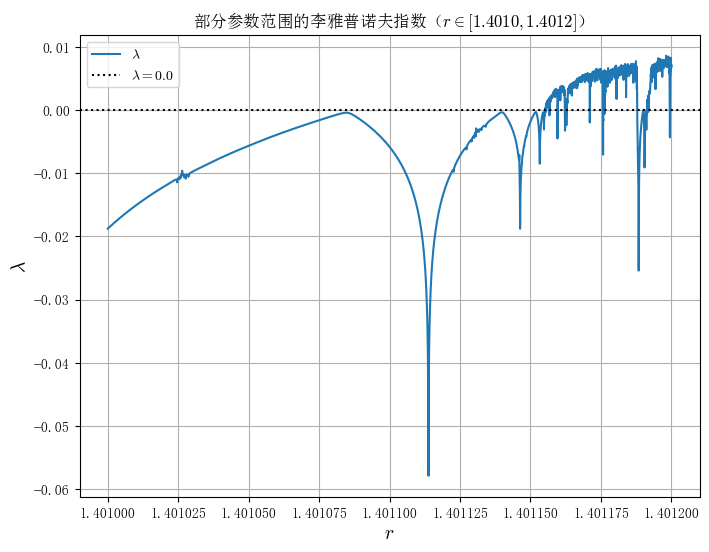

可以发现，混沌区大约在 $r\approx1.40115$ 出现. 我们取 $r\in[0,1.40115]$. 并写出如下函数得到 $r\in [0,1.40115]$ 的周期数随 $r$ 的变化关系：

> 为了加速，这里使用 `numba` 进行 jit 加速以及并行计算加速，第一次运行可能需要有几秒的编译时间

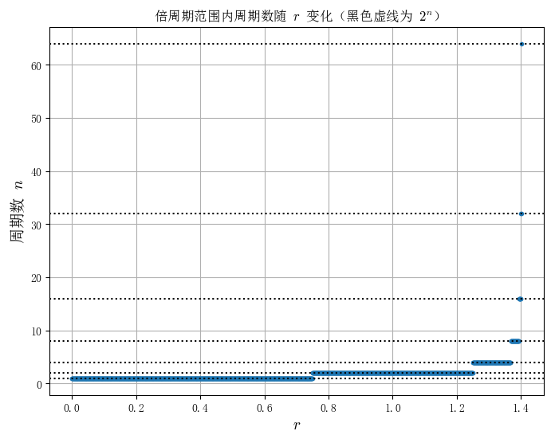

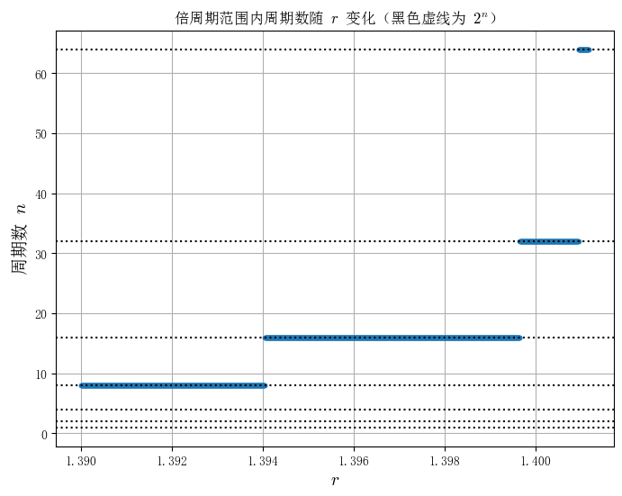

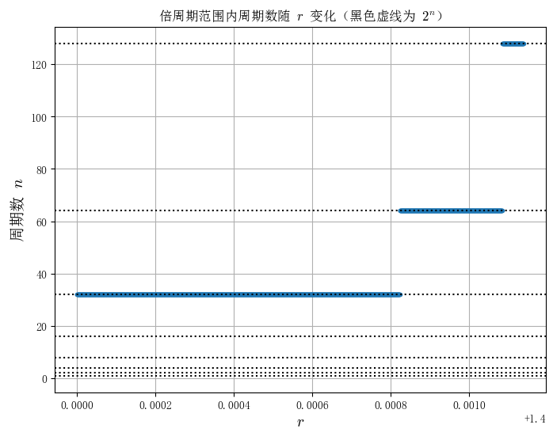

从中我们可以得到每个倍周期分叉点的低精度估计：

```
1  -> 2   倍周期分叉点估计: 0.749642
2  -> 4   倍周期分叉点估计: 1.250105
4  -> 8   倍周期分叉点估计: 1.367861
8  -> 16  倍周期分叉点估计: 1.394039
16 -> 32  倍周期分叉点估计: 1.399644
32 -> 64  倍周期分叉点估计: 1.400823
64 -> 128 倍周期分叉点估计: 1.401084
```

#### 细化（0.618 法）

由于后面的费根鲍姆常数需要较高精度的倍周期分叉点，因此，这里需要进一步细化分叉点的值.

首先，前面我们得到了倍周期分叉点的估计，记为 $p_k$，由于这里的倍周期分叉点是不够精确的，因此这里需要使用二分法或者 0.618 法进一步细化，这就需要给出包含且只包含每个分叉点的小区间，这里按照如下方法定义：

对于分叉点 $p_k$，构造小区间为：

$$ \left( p_k - \frac{1}{2} (p_k - p_{k-1}), p_k + \frac{1}{2} (p_{k+1} - p_{k}) \right) $$

（头尾两个设半径为 `0.001`）从而得到：

```
1  -> 2   倍周期分叉点估计范围: 0.748642 到 0.750642
2  -> 4   倍周期分叉点估计范围: 0.999874 到 1.308983
4  -> 8   倍周期分叉点估计范围: 1.308983 到 1.380950
8  -> 16  倍周期分叉点估计范围: 1.380950 到 1.396842
16 -> 32  倍周期分叉点估计范围: 1.396842 到 1.400234
32 -> 64  倍周期分叉点估计范围: 1.400234 到 1.400954
64 -> 128 倍周期分叉点估计范围: 1.400084 到 1.402084
```

对于每一个区间，我们知道，当位于倍周期分叉点时，$\lambda=0$，而不在倍周期分叉点时，$\lambda<0$，因此，倍周期分叉点在小区间内满足 $\lambda$ 为最值.

因此，我们将在小区间内寻找倍周期分叉点的问题转化为一个优化问题，且这个函数在每个区间内是“单峰的”，因此我们可以使用梯度上升法（通过差分近似微分估计梯度），0.618 法等多种数值方法来找最值.

这里我们使用 0.618 法，具体过程如下：

1. 给定边界 $[a,b]$，计算其中的两个黄金分割位置 $c,d$，其中 $c = a + (b-a)/\phi $，$d = b - (b-a)/\phi $，$\phi$ 为黄金分割比
2. 计算点 $c$ 和点 $d$ 位置的李雅普诺夫指数，并比较大小，若 $\lambda_{c} > \lambda_{d}$，则跳转第三步，否则跳转第四步
3. 令 $b \to d$，$d \to c$ 回到第一步
4. 令 $a \to c$，$c \to d$ 回到第一步
5. 重复上述过程，直到最后满足 $b-a < \text{tol}$

上述 0.618 法细化过程如下：

```
1  -> 2   倍周期分叉点: 0.749965
2  -> 4   倍周期分叉点: 1.249983
4  -> 8   倍周期分叉点: 1.368091
8  -> 16  倍周期分叉点: 1.394043
16 -> 32  倍周期分叉点: 1.399630
32 -> 64  倍周期分叉点: 1.400828
64 -> 128 倍周期分叉点: 1.400828
```

最后一个 64 到 128 的倍周期分叉点显然有问题，可能是因为我们的初始范围定的不好（考虑到最后一个点的初始范围是人为定的），这里暂时略去.

同时，对比我们已经知道的 1 到 2 分叉点（0.75），2 到 4 分叉点（1.25），上面的数值计算还是较为准确的.

因此，我们得到了数值计算的倍周期分叉点，如下：

```
1  -> 2  倍周期分叉点: 0.749965
2  -> 4  倍周期分叉点: 1.249983
4  -> 8  倍周期分叉点: 1.368091
8  -> 16 倍周期分叉点: 1.394043
16 -> 32 倍周期分叉点: 1.399630
32 -> 64 倍周期分叉点: 1.400828
```

### $r_{\infty}$

#### 初筛

在前面全参数范围的李雅普诺夫指数的图中，我们知道混沌取大约在 $r\approx1.40115$ 出现，我们在这个数邻域放大李雅普诺夫指数：

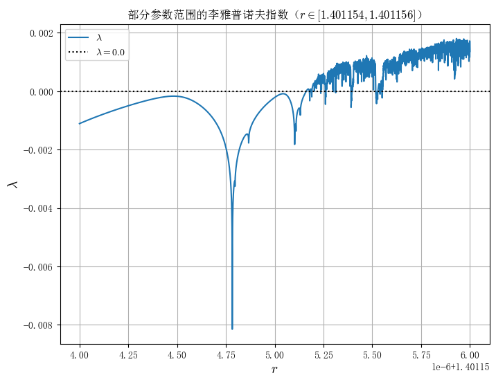

$\displaystyle 1.40115516223245$

因此，一个 $r_{\infty}$ 的粗略估计为 $r_{\infty} = 1.401155$

#### 细化（二分法）

同样，我们需要细化上面的计算，这里由于 $\lambda$ 在 $r_{\infty}$ 两侧变号，比较适合二分法，因此这里使用二分法进行细化，初始邻域宽度定为：$10^{-6}$

$\displaystyle 1.40115521878052$

因此，我们得到了数值计算的 $r_{\infty} = 1.40115522\dots$

### 验证倍周期分叉点和 $r_{\infty}$

我们将前面计算的倍周期分叉点和 $r_{\infty}$ 在分叉图中标准以验证：

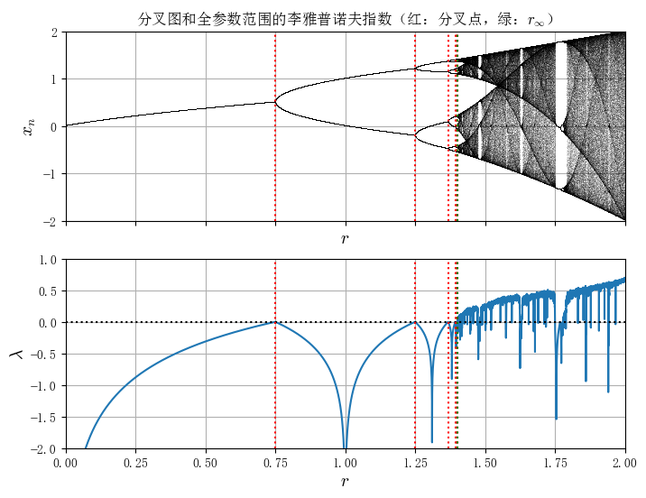

在接近混沌区放大：

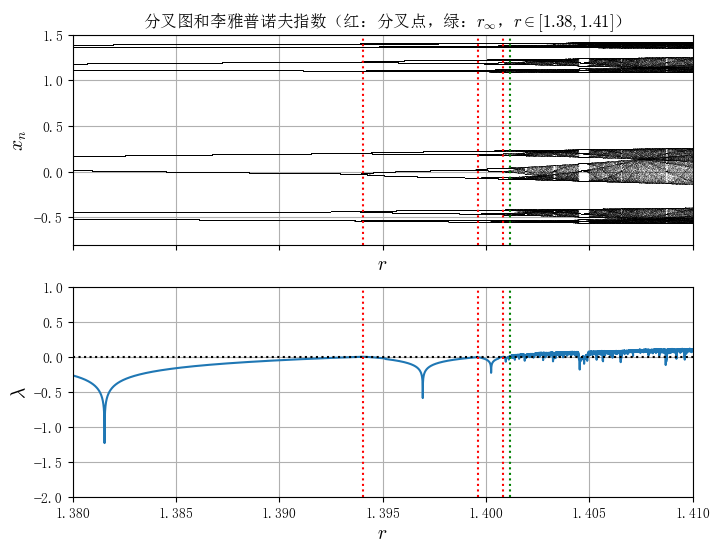

可以发现，我们的分叉点和 $r_{\infty}$ 还是比较准确的.